# LESSON 7: MATPLOTLIB INTRODUCTION

## 4. Plot title, label, legend and text

### 4.1. Add title

```python
x = np.linspace(-5, 5, 50)
```

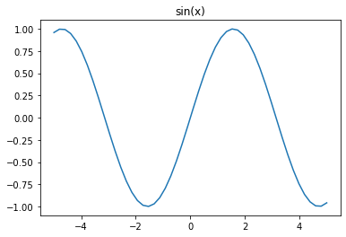

```python
plt.plot(x, np.sin(x))
plt.title("sin(x)")
plt.show()
```

### 4.2. Add label

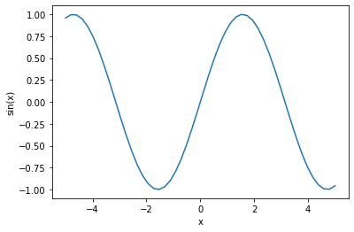

```python
plt.plot(x, np.sin(x))
plt.xlabel("x")
plt.ylabel("sin(x)")
plt.show()
```

### 4.3. Add legend

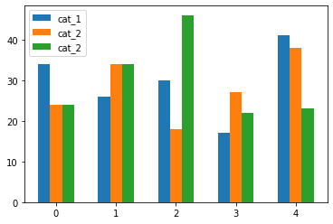

```python
plt.bar(index-0.2, value_1, width=0.2, label='cat_1')
plt.bar(index, value_2, width=0.2, label='cat_2')
plt.bar(index+0.2, value_3, width=0.2, label='cat_2')
plt.legend()
plt.show()
```

### 4.4. All title, label and legend

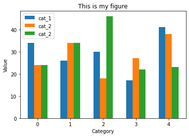

```python
plt.bar(index-0.2, value_1, width=0.2, label='cat_1')
plt.bar(index, value_2, width=0.2, label='cat_2')
plt.bar(index+0.2, value_3, width=0.2, label='cat_2')
plt.legend(loc='upper left')
plt.xlabel("Category")
plt.ylabel("Value")
plt.title("This is my figure")
plt.show()
```

### 4.5. Add text

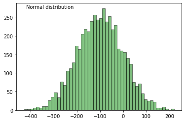

```python
plt.hist(y,                 # data
         bins=50,           # number of bar
         alpha=0.5,         # opacity
         color='green',     # bar color
         edgecolor='black') # edge of bar color
plt.text(-420, 275, r'Normal distribution')
plt.show()
```

### 4.6. Annotate figure

```python
plt.hist(y,                 # data
         bins=50,           # number of bar
         alpha=0.5,         # opacity
         color='green',     # bar color
         edgecolor='black') # edge of bar color
plt.annotate('mean',
             xy=(-100, 310),
             xytext=(100, 300),
             arrowprops=dict(facecolor='black'))
plt.show()
```

[output not shown]

## 5. Axes limit in `plt.plot()` or `plt.hist()`

### 5.1. Using `plt.xlim()` and `plt.ylim()`

#### Normal plot

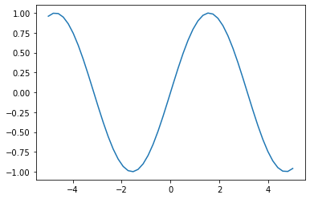

```python
plt.plot(x, np.sin(x))
plt.show()
```

#### With `plt.xlim()` and `plt.ylim()`

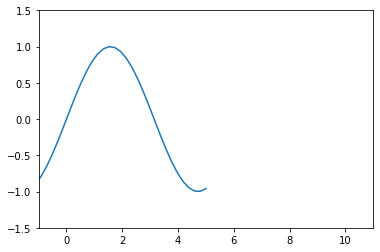

```python
plt.plot(x, np.sin(x))
plt.xlim(-1, 11)
plt.ylim(-1.5, 1.5)
plt.show()
```

#### Reverse the axis

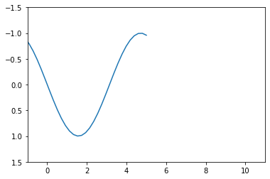

```python
plt.plot(x, np.sin(x))

plt.xlim(-1, 11)
plt.ylim(1.5, -1.5)
plt.show()
```

#### With `plt.hist()`

```python
plt.hist(y,                 # data
         bins=50,           # number of bar
         alpha=0.5,         # opacity
         color='green',     # bar color
         edgecolor='black') # edge of bar color
plt.show()
```

[output not shown]

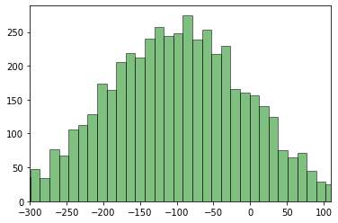

```python
plt.hist(y,                 # data
         bins=50,           # number of bar
         alpha=0.5,         # opacity
         color='green',     # bar color
         edgecolor='black') # edge of bar color
plt.xlim(-300, 110)
plt.show()
```

### 5.2. Limit axes by `plt.axis()`

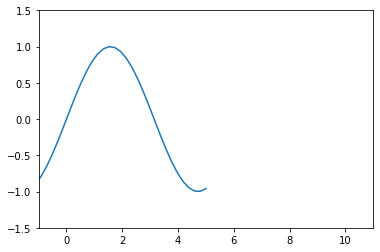

```python
plt.plot(x, np.sin(x))
plt.axis([-1, 11, -1.5, 1.5])
plt.show()
```

### 5.3. Automatically limit axis

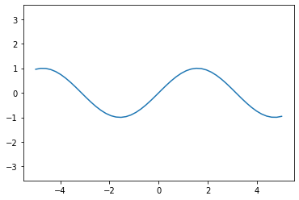

```python
plt.plot(x, np.sin(x))
plt.axis('equal') # ensure aspect ratio
plt.show()
```

## 6. Subplots - Multiple plots

### 6.1. Create single sub-plot by `plt.subplot()`

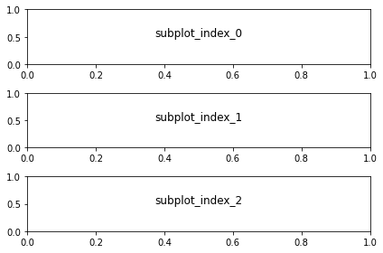

```python
for subplot_index in range(3):
    plt.subplot(3, 1, subplot_index+1)
    plt.text(0.5, 0.5, f'subplot_index_{subplot_index}', fontsize=12, horizontalalignment='center')
# Add space between subplots
plt.tight_layout()
plt.show()
```

### 6.2. Create the whole sub-plots by `plt.subplots()`

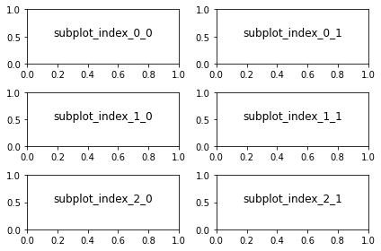

```python
num_rows, num_cols = 3, 2
fig, ax = plt.subplots(num_rows, num_cols)

for row_index in range(num_rows):
    for col_index in range(num_cols):
        ax[row_index, col_index].text(
            0.5, 0.5, f'subplot_index_{row_index}_{col_index}', fontsize=12, horizontalalignment='center')

# Add space between subplots
plt.tight_layout()
plt.show()
```

### 6.3. More specific subplots by using `plt.GridSpec()`

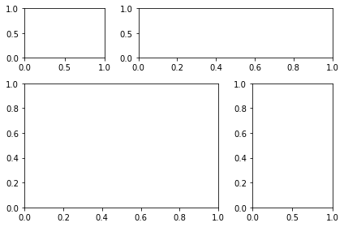

```python
grid = plt.GridSpec(3, 3)

plt.subplot(grid[0, 0])
plt.subplot(grid[0, 1:])
plt.subplot(grid[1:, :2])
plt.subplot(grid[1:, 2])
# Add space between subplots
plt.tight_layout()
plt.show()
```

### 6.4. Multiple plots in one figure by `twinx()`

```python
x = np.linspace(-5, 5, 50)
```

[figure not shown]

```python
fig, ax_1 = plt.subplots()

ax_1.plot(x, np.sin(x), label='sin(x)')
ax_1.set_ylabel('sin(x)')

ax_2 = ax_1.twinx()
ax_2.plot(x, np.exp(x), 'r.-', label='exp(x)')
ax_2.set_ylabel('exp(x)')

fig.legend(loc='upper left')
plt.show()
```

```python
x = np.arange(1, 11)
y = np.random.randint(0, 100, 10)
z = np.random.randint(0, 100, 10)
```

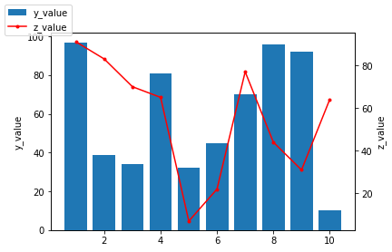

```python
fig, ax_1 = plt.subplots()

ax_1.bar(x, y, label='y_value')
ax_1.set_ylabel('y_value')

ax_2 = ax_1.twinx()
ax_2.plot(x, z, 'r.-', label='z_value')
ax_2.set_ylabel('z_value')

fig.legend(loc='upper left')
plt.show()
```

## 7. Homework

Note:

- We use the daily historical sales data from previous lecture in this homework.
- All figures must have title, label and legend.

### 7.1. Exercise 1:

Randomly choose 3 shops, use `one line plot figure` to show the total turnover of them each month over 33 months (from January 2013 is 0, February 2013 is 1,..., October 2015 is 33.)

### 7.2. Exercise 2:

Randomly choose 1 item, use `one combo figure with bar plot and line plot` to show the sales and the turnover of them over 33 months (from January 2013 is 0, February 2013 is 1,..., October 2015 is 33.)

### 7.3. Exercise 3:

Randomly choose 3 items, use `one bar plot figure` to show the sales of them in 3 years 2013, 2014, and 2015.

### 7.4. Exercise 4:

Randomly choose 1 shop, use `stack plot figure` to show the contribution of turnover of each item each month over 33 months (from January 2013 is 0, February 2013 is 1,..., October 2015 is 33.)

### 7.5. Exercise 5:

Randomly choose 1 shop, use `pie plot figure` to show the contribution of turnover (in percent) of each item in 3 years 2013, 2014, and 2015. (1 pie plot figure for each year, use `subplots` to put all 3 figures together)

### 7.6. Exercise 6:

Randomly choose 1 item, use `histogram figure` to show the distribution of sales of the item over 33 months (from January 2013 is 0, February 2013 is 1,..., October 2015 is 33.)